# Advanced Visualisation in R

…и почему вам это надо

Stepan Polikanov

2022-06-28

# Н-н-но я и так могу визуализировать данные…

Люди работающие с данными, особенно в академическом сообществе, в среднем не умеют их хорошо визуализировать.

- Очевидность для вас трендов, паттернов и зависимостей в данных легче всего представить в графике, это соединяет аналитика и смотрящего (начальника, рецензента, коллаборанта);
- Важно правильно устанавливать контекст данных, правильные визуализации дают правильное представление о том, что происходит:

Что не так с этим графиком?

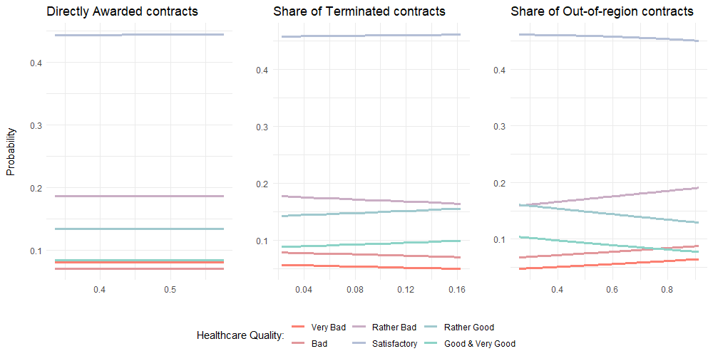

- Работодатели (должны) на это надрачивают, это всегда плюс.

# База

Несмотря на то, что под визуализацию данных можно подвести, например, построение наглядных таблиц, чаще всего, вам будет нужно строить графики для одной из трёх целей:

- Разведывательный анализ данных;
- Визуализация результатов моделей;
- Анализ переменных, изменяющихся во времени.

Лучшие практики:

- График должен говорить сам за себя - читатель не должен читать Ваш текст, чтобы понять график (обязательно: название, источник, названия осей, легенда, подписи к выделенным элементам);
- Не должно быть мусора: лишние эстетические элементы, дубликация информации, цвета;
- Масштабирование оси y.

ggplot2, работает на основе пайпов, схоже, например, с dplyr. Каждый следующий элемент добавляется при помощи + к уже имеющимся. Минимум для построения графика - это датасет, переменные и geom (графическое представление данных на графике - точки, линии, столбцы). [Введение](https://rkabacoff.github.io/datavis/preface.html) в визуализацию данных в R, [чит-лист](http://r-statistics.co/ggplot2-cheatsheet.html) для работы с элементами ggplot, [мастер список визуализаций](http://r-statistics.co/Top50-Ggplot2-Visualizations-MasterList-R-Code.html).

## Распределения

Мы будем использовать базовый датасет про зарплаты профессоров из пакета [carData](https://www.rdocumentation.org/packages/carData/versions/3.0-1/topics/Salaries).

```r
require(ggplot2)
require(dplyr)
require(ggExtra)
require(ggpubr)
require(ggalt)
require(remotes)
require(ggcorrplot)
require(lubridate)
require(forecast)
require(RColorBrewer)
remotes::install_github("talegari/sidekicks")
library(sidekicks)

data(Salaries, package="carData")
```

Визуализируем категориальную переменную rank, используя столбиковую диаграмму geom_bar.

```r
# Преобразовываем категориальные переменные в красивые названия
Salaries$rank <- factor(Salaries$rank, levels = c('Prof', 'AsstProf', 'AssocProf'),
                        labels = c('Full Professor', 'Assistant Professor',
                                   'Associate Professor'))

Salaries$discipline <- factor(Salaries$discipline, levels = c('A', 'B'),
                        labels = c('Theoretical', 'Applied'))

head(Salaries)
```

|  | rank | discipline | yrs.since.phd | yrs.service | sex | salary |
| --- | --- | --- | --- | --- | --- | --- |
| 1 | Full Professor | Applied | 19 | 18 | Male | 139750 |
| 2 | Full Professor | Applied | 20 | 16 | Male | 173200 |
| 3 | Assistant Professor | Applied | 4 | 3 | Male | 79750 |
| 4 | Full Professor | Applied | 45 | 39 | Male | 115000 |
| 5 | Full Professor | Applied | 40 | 41 | Male | 141500 |
| 6 | Associate Professor | Applied | 6 | 6 | Male | 97000 |

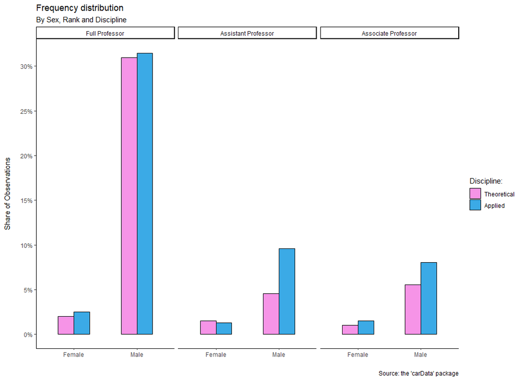

```r
# Преобразование для frequency распределения
plot_counts <- Salaries %>%
  count(rank, sex, discipline)%>%
  mutate(pct = n/sum(n))

ggplot(plot_counts,
       aes(x = sex,
           y = pct,
           fill = discipline)) +
  geom_bar(stat = 'identity',
           position = 'dodge',
           width = .5,
           color = 'black') +
  scale_fill_manual(values = c('#F694E7', '#3BAAE6')) +
  scale_y_continuous(breaks = seq(0, 0.35, 0.05),
                     labels = scales::percent) +
  facet_grid(~ rank) + # делим на графики
  labs(subtitle = "By Sex, Rank and Discipline", # подназвание
       y = "Share of Observations\n",
       x = "", # Опускаем название оси x, так как male/ female самоочевидны
       fill = 'Discipline:', # название легенды
       title = "Frequency distribution", # название
       caption = "Source: the 'carData' package") + # сурс
  theme_classic() # чтобы были хорошо разделены категории на графике
```

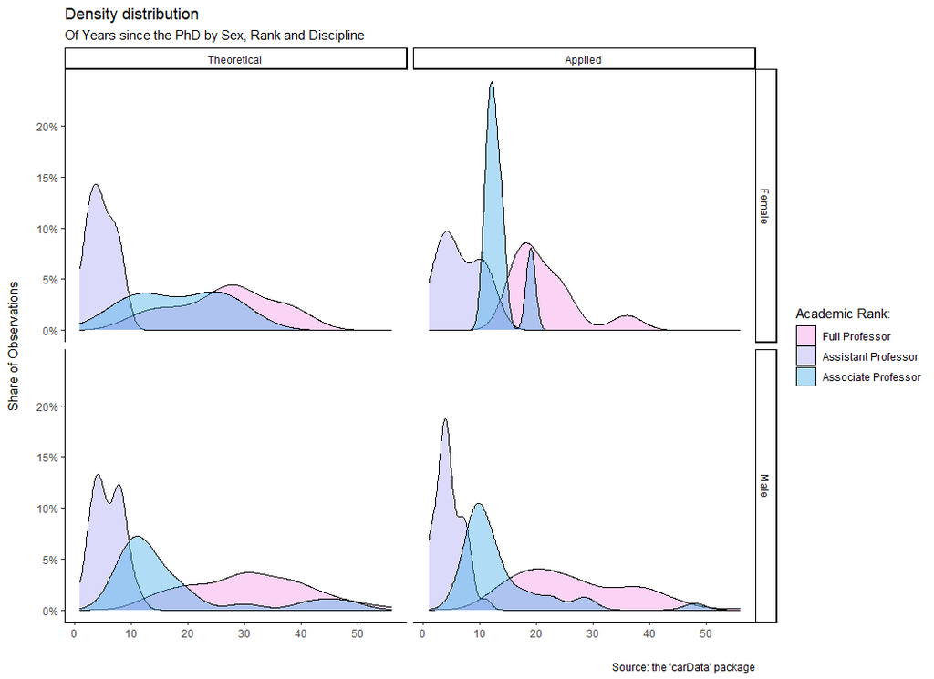

```r
ggplot(Salaries,
       aes(x = yrs.since.phd,
           fill = rank)) +
  geom_density(alpha = 0.4) +
  scale_y_continuous(breaks = seq(0, 0.2, 0.05),
                     labels = scales::percent) +
  scale_x_continuous(breaks = seq(0, 60, 10)) +
  scale_fill_manual(values = c('#F694E7', '#A6A3F4', '#3AAAE6')) +
  labs(subtitle = "Of Years since the PhD by Sex, Rank and Discipline",
       y = "Share of Observations\n",
       x = "",
       fill = 'Academic Rank:',
       title = "Density distribution",
       caption = "Source: the 'carData' package") +
  facet_grid(sex ~ discipline) + # так, чтобы получить и строки и столбцы
  theme_classic()
```

## Корреляции

Самоё полезное, что можно включить в свою работу помимо дескриптивных статистик, это корреляции между переменными, удобнее всего получить их - с помощью коррелограммы. Проблема заключается в том, чаще всего это плохо работает с переменными разных типов, хотя методы подсчёта самих корреляций существуют. Я использую пользовательский пакет (с пакетами) sidekicks с гитхаба:

```r
corr <- as.matrix(cor2(Salaries), labels = TRUE)
colnames(corr) <- rownames(corr) <- c('Rank', 'Discipline',
                                     'Years Since PhD',
                                     'Years of service',
                                     'Sex', 'Salary')

corr
```

```
                      Rank  Discipline Years Since PhD Years of service         Sex
Rank             0.0000000 0.108210767       0.7017834        0.6086038 0.146546590
Discipline       0.1082108 0.000000000       0.2180873        0.1645987 0.003723739
Years Since PhD  0.7017834 0.218087325       0.0000000        0.9096491 0.148787792
Years of service 0.6086038 0.164598697       0.9096491        0.0000000 0.153739575
Sex              0.1465466 0.003723739       0.1487878        0.1537396 0.000000000
Salary           0.6278944 0.156083946       0.4192311        0.3347447 0.138610169
                    Salary
Rank             0.6278944
Discipline       0.1560839
Years Since PhD  0.4192311
Years of service 0.3347447
Sex              0.1386102
Salary           0.0000000
```

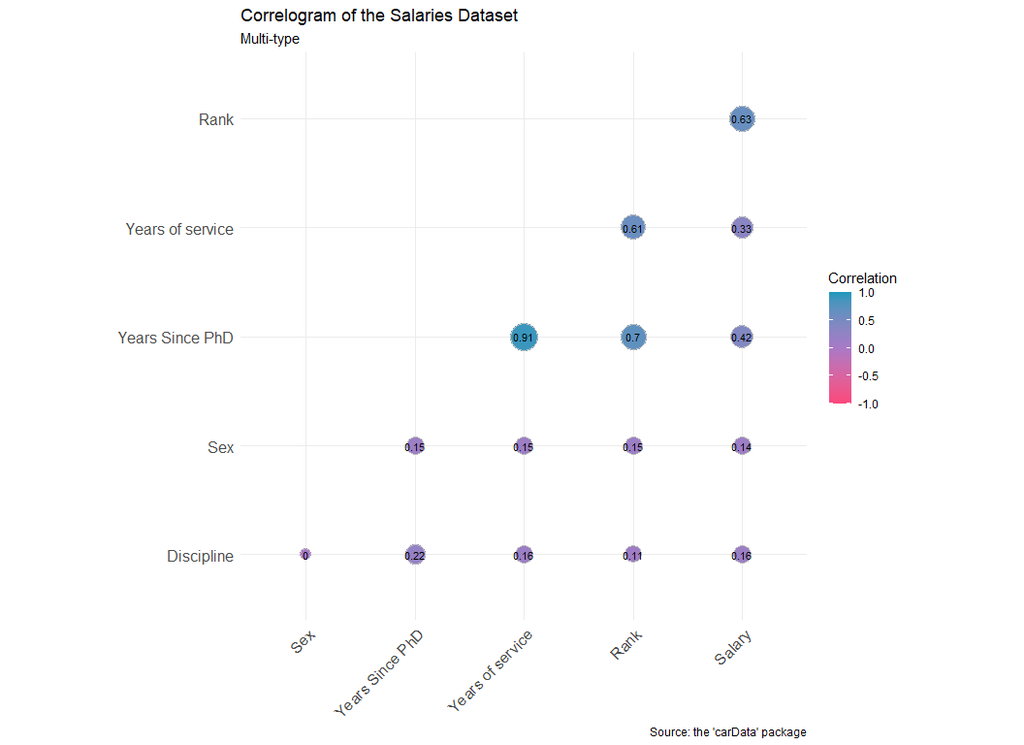

```r
ggcorrplot(corr, hc.order = T,
           type = "lower", # нижняя часть матрицы
           lab = TRUE, # коэффициенты
           lab_size = 3,
           method = "circle",
           colors = c("#FC467A", "#A979C7", "#1D98BC"),
           legend.title = 'Correlation',
           ggtheme = theme_minimal) +
  labs(subtitle = "Multi-type",
       title = "Correlogram of the Salaries Dataset",
       caption = "Source: the 'carData' package")
```

Начнём с базовых scatterplots, показывающих взаимосвязь двух непрерывных переменных, с разделением по категориальным переменным.

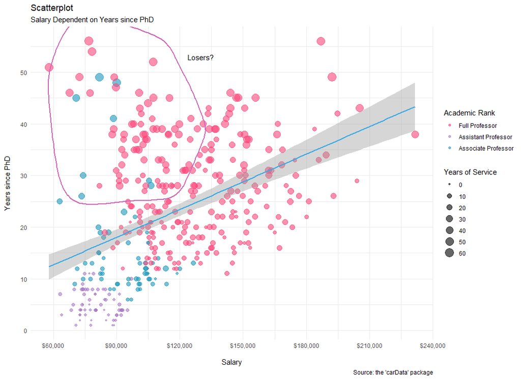

```r
library(ggalt)
lower_half <- Salaries[Salaries$salary > 60000 &
                       Salaries$salary <= 120000 &
                       Salaries$yrs.since.phd >= 30 &
                       Salaries$yrs.since.phd < 57,]

ggplot(Salaries,
       aes(x = salary,
           y = yrs.since.phd)) +
  geom_point(aes(col = rank, size = yrs.service), # Разбивка по категориальным переменным
             alpha = 0.6) + # Прозрачность
  geom_smooth(method = "lm", formula = "y ~ x", color = '#3AAAE6') +
  scale_x_continuous(breaks = seq(0, 240000, 30000),
                     label = scales::dollar) +
  scale_y_continuous(breaks = seq(0, 60, 10)) +
  scale_color_manual(values = c("#FC467A", "#A979C7", "#1D98BC"))+ # цвета
  geom_encircle(aes(x = salary, y = yrs.since.phd), # обведём интересующую группу
                data = lower_half,
                color = "#CE68B6",
                size = 2,
                expand=0.08) +
annotate(geom = "text", x = 130000, y = 53, # Подпись
         label = "Losers?") +
  labs(subtitle = "Salary Dependent on Years since PhD",
       y = "Years since PhD\n",
       x = "\nSalary",
       col = "Academic Rank",
       size = "Years of Service",
       title = "Scatterplot",
       caption = "Source: the 'carData' package") +
  theme_minimal()
```

В ситуациях, когда две переменные имеют схожие шкалы, при построении scatterplot’а могут возникать дублицированные точки, выглядит это примерно вот так:

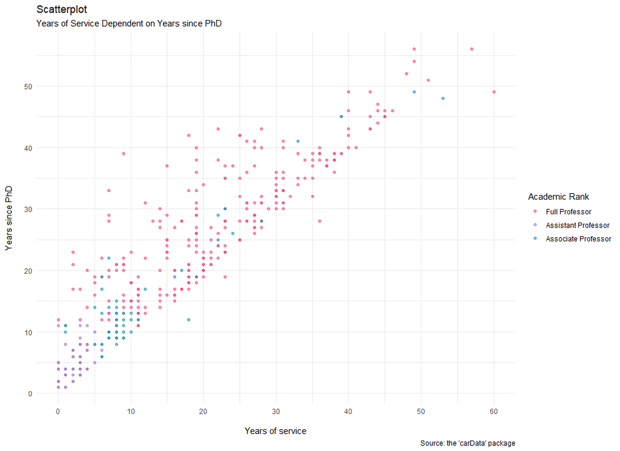

```r
ggplot(Salaries,
       aes(x = yrs.service,
           y = yrs.since.phd)) +
  geom_point(aes(col = rank), alpha = 0.6) +
  scale_x_continuous(breaks = seq(0, 60, 10)) +
  scale_y_continuous(breaks = seq(0, 60, 10)) +
  scale_color_manual(values = c("#FC467A", "#A979C7", "#1D98BC"))+
  labs(subtitle = "Years of Service Dependent on Years since PhD",
       y = "Years since PhD\n",
       x = "\nYears of service",
       col = "Academic Rank",
       title = "Scatterplot",
       caption = "Source: the 'carData' package") +
  theme_minimal()
```

В таком случае уместно добавить jitter - рандомно распределённые точки рядом с оригинальной дублицированной позицией.

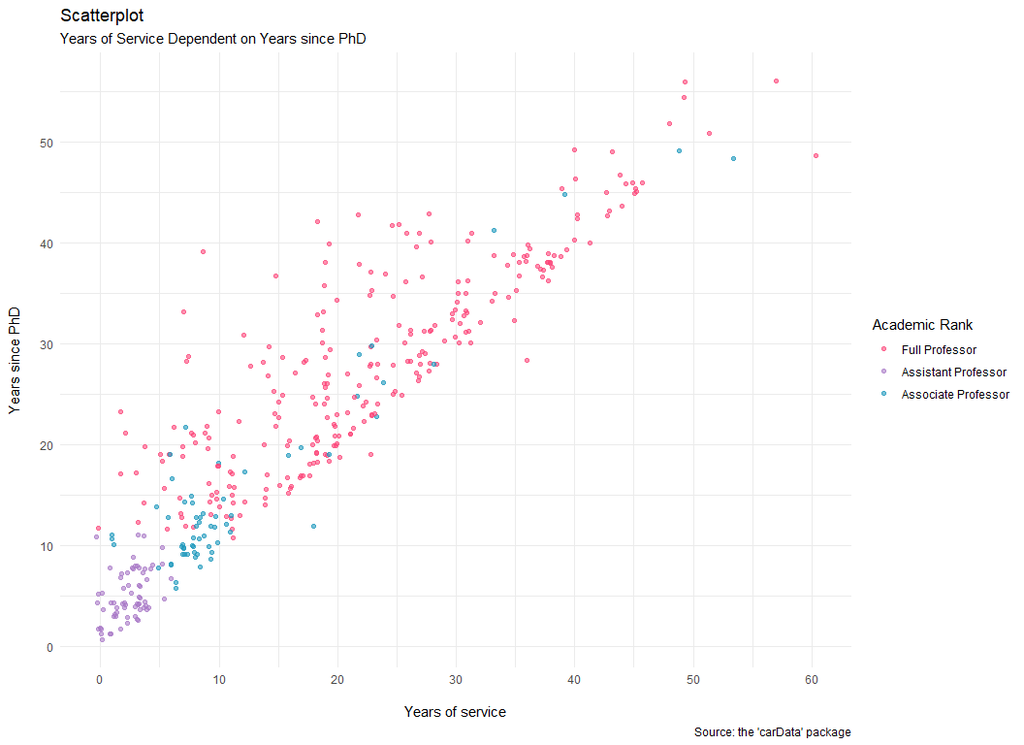

```r
ggplot(Salaries,
       aes(x = yrs.service,
           y = yrs.since.phd)) +
  geom_jitter(aes(col = rank), alpha = 0.6) + # jitter
  scale_x_continuous(breaks = seq(0, 60, 10)) +
  scale_y_continuous(breaks = seq(0, 60, 10)) +
  scale_color_manual(values = c("#FC467A", "#A979C7", "#1D98BC"))+
  labs(subtitle = "Years of Service Dependent on Years since PhD",
       y = "Years since PhD\n",
       x = "\nYears of service",
       col = "Academic Rank",
       title = "Scatterplot",
       caption = "Source: the 'carData' package") +
  theme_minimal()
```

Если вам (грязным извращенцам) угодно поместить на один график и density/histogram/boxplot распределения переменных и scatterplot, можно сделать следующее:

```r
scat <- ggplot(Salaries,
               aes(x = salary,
                   y = yrs.since.phd)) +
        geom_point(aes(col = rank, size = yrs.service), alpha = 0.6) +
        geom_smooth(method = "lm", formula = "y ~ x", color = '#3AAAE6') +
        scale_x_continuous(breaks = seq(0, 240000, 30000),
                           label = scales::dollar) +
        scale_y_continuous(breaks = seq(0, 60, 10)) +
        scale_color_manual(values = c("#FC467A", "#A979C7", "#1D98BC")) +
        labs(subtitle = "Salary Dependent on Years since PhD",
             y = "Years since PhD\n",
             x = "\nSalary",
             col = "Academic Rank",
             size = "Years of Service",
             title = "Scatterplot",
             caption = "Source: the 'carData' package") +
        theme_minimal() +
    theme(legend.position = "left")

dens <- ggMarginal(scat, type = 'density', groupFill = T)
hist <- ggMarginal(scat, type = 'histogram', groupFill = T)
box <- ggMarginal(scat, type = 'boxplot', groupFill = T)
```

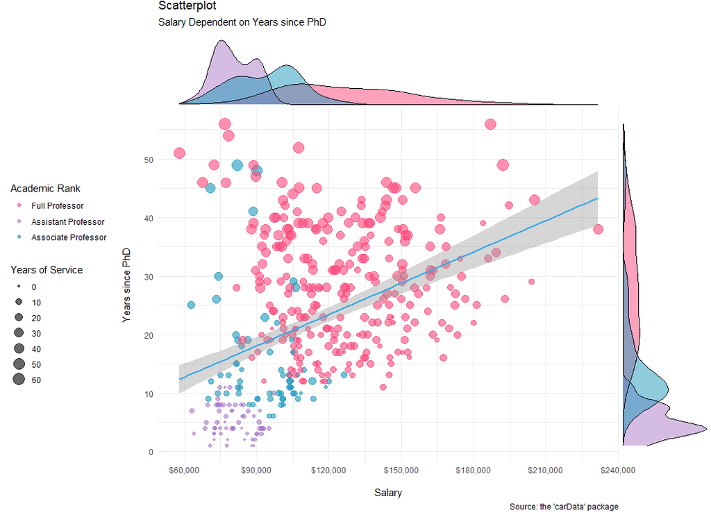

```r
dens
```

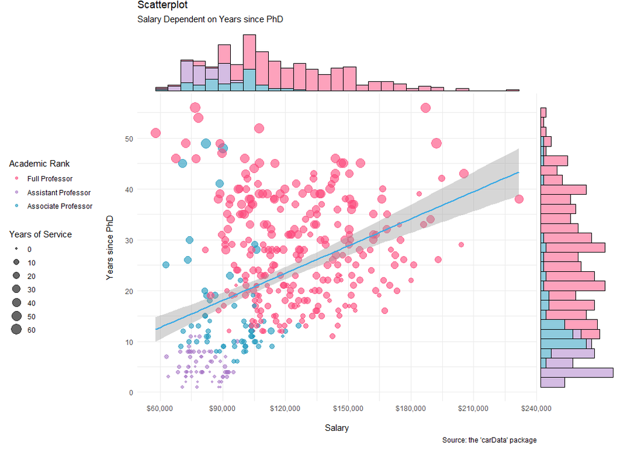

```r
hist
```

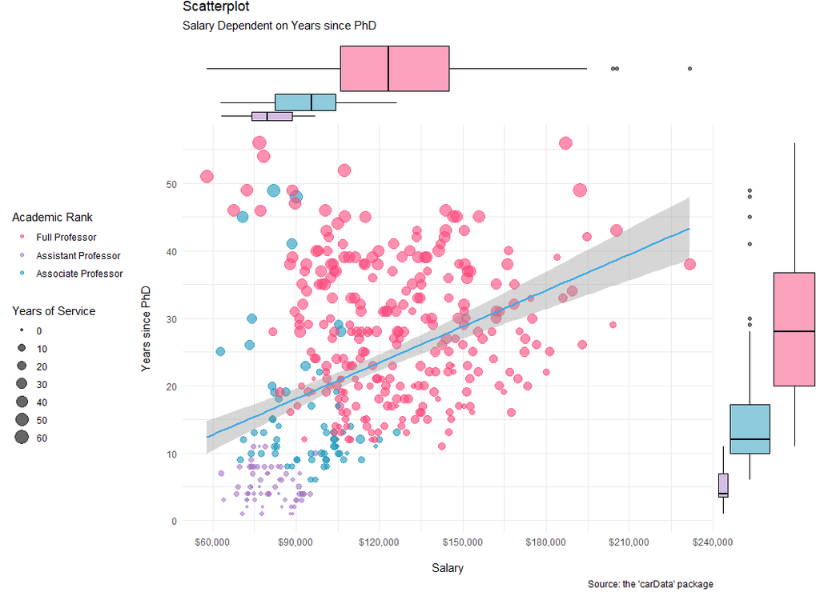

```r
box
```

## Time Series

Наконец, давайте посмотрим на визуализации time series на датасете Economics.

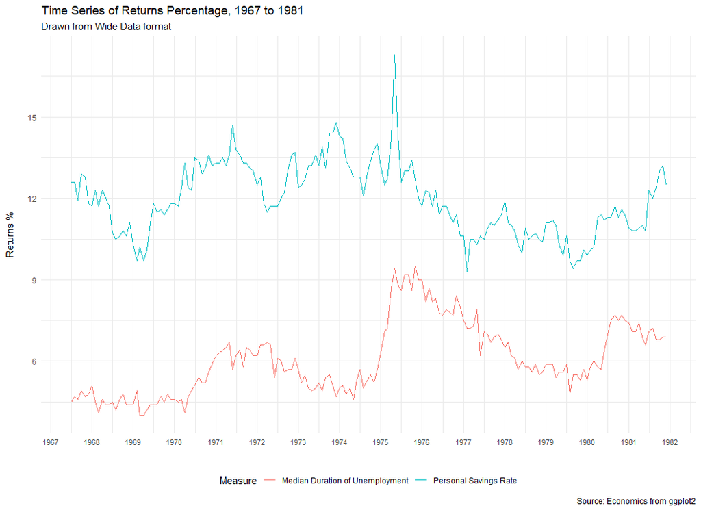

```r
data(economics, package="ggplot2")

economics <- economics %>%
  select("date", 'Personal Savings Rate' = "psavert", 'Median Duration of Unemployment' = "uempmed")

econ <- economics[lubridate::year(economics$date) %in% c(1967:1981), ]
# plot
ggplot(econ, aes(x = date)) +
  geom_line(aes(y = `Personal Savings Rate`, col = 'Personal Savings Rate')) +
  geom_line(aes(y = `Median Duration of Unemployment`, col = 'Median Duration of Unemployment')) +
  labs(title = "Time Series of Returns Percentage, 1967 to 1981",
       subtitle = "Drawn from Wide Data format",
       caption = "Source: Economics from ggplot2",
       y = "Returns %\n",
       x = '',
       col = 'Measure') +
  scale_x_date(date_labels = "%Y",
               date_breaks = '1 year') +
  theme_minimal() +
  theme(axis.text.x = element_text(vjust=0.5, size = 8),
        legend.position = 'bottom')
```

Месячный график по годам:

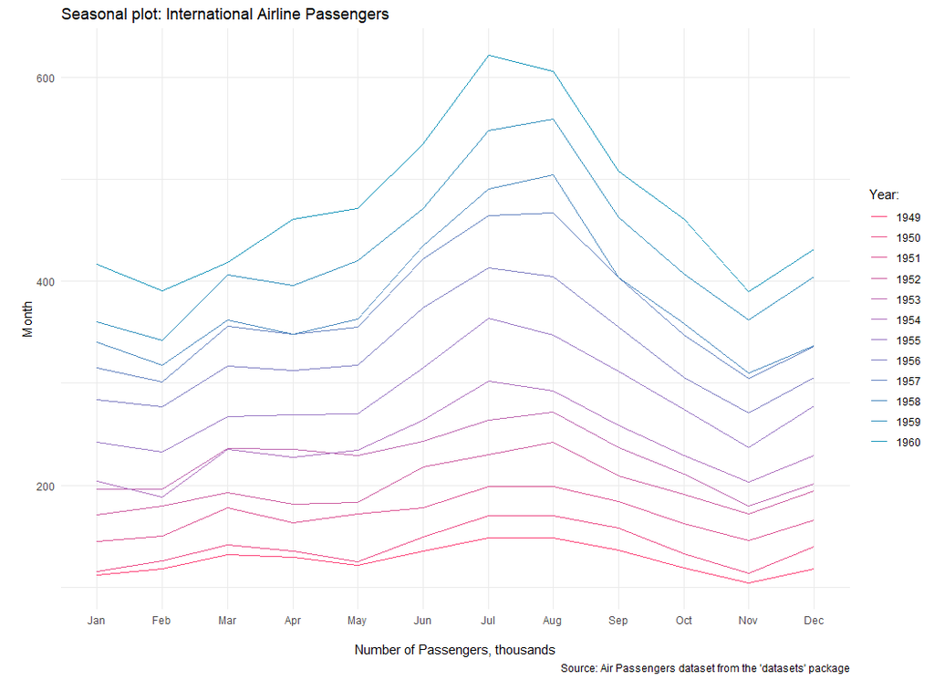

```r
ggseasonplot(AirPassengers,
             col = colorRampPalette(c("#FC467A", "#A979C7", "#1D98BC"))(12)) +
  labs(title = "Seasonal plot: International Airline Passengers",
       x = '\nNumber of Passengers, thousands',
       y = '\nMonth',
       color = 'Year:',
       caption = "Source: Air Passengers dataset from the 'datasets' package") +
  theme_minimal()
```